# Toymodel

Charley Ferrari

November 30, 2015

So for the effect of migration of employment, I’m starting with a simple employment model. I defined two critical values: a “slack” and a “capacity” population number.

Capacity is meant to be the capacity of the economy, and I defined it as the point at which 1 additional person will result in 0 additional jobs. Slack is meant to be a very underutilized economy, where 1 additional person adds 1 additional job (we could even imagine situations where 1 more person adds more than 1 job, but to keep things simple I created a 1-1 zone here.)

Here’s a graph showing this model, x axis is the population, while y is the number of jobs added by 1 marginal person at that population. If the population is greater than capacity, this number is 0. If it’s less than slack, it’s 1. And, if it’s between slack and capacity, I just made it a linear function.

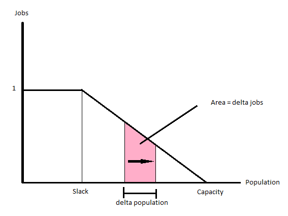

Since we’re looking at marginal jobs, the area under the curve is the number of jobs we’re adding in total.

Now, lets look at a situation where we’re at capacity in two regions. I defined a “frictional” unemployment rate of 2% at this capacity:

```r
totalPop <- 10000

capacity <- c(5000,5000)

slack <- c(4000,4000)

capjobs <- 0.98*capacity

UE <- 1-(capjobs/capacity)

avgUE <- sum((capacity/totalPop)*UE)

avgUE
```

```
## [1] 0.02
```

I took an average UE by weighting the unemployment rate by population. Now, I’ll define some functions to help me out:

marginalJobs: given a population, slack, and capacity, calculates the marginal number of jobs added from an increase in population.

numjobsraw: calculates the area under the curve from p1 to p2 (negative if p1 > p2)

numjobs: uses numjobsraw, and has a series of if-else statements to calculate the area under the curve even if populations are below slack or above capacity.

```r
marginaljobs <- function(p, capacity, slack){
  return((capacity - p)/(capacity - slack))
}

intmarginaljobs <- function(p, capacity, slack){
  imj <- (2*capacity*p - p^2)/(2*capacity - 2*slack)
  return(imj)
}

numjobsraw <- function(p1,p2,capacity,slack){
  nj <- intmarginaljobs(p2,capacity,slack) -
    intmarginaljobs(p1,capacity,slack)
  return(nj)
}

numjobs <- function(p1,p2,capacity,slack){
  if(p1 < slack){
    if(p2 < slack){
      #print(1)
      return((p2-p1))
    }else if(p2 >= slack && p2 < capacity){
      nj <- (slack-p1) + numjobsraw(slack,p2,capacity,slack)
      #print(2)
      return(nj)
    }else{
      nj <- (slack-p1) + numjobsraw(slack,capacity,capacity,slack)
      #print(3)
      return(nj)
    }

  }else if(p1 >= slack && p1 < capacity){
    if(p2 < slack){
      nj <- (p2-slack) + numjobsraw(p1,slack,capacity,slack)
      #print(4)
      return(nj)
    }else if(p2 >= slack && p2 < capacity){
      nj <- numjobsraw(p1,p2,capacity,slack)
      #print(5)
      return(nj)
    }else{
      nj <- numjobsraw(p1,capacity,capacity,slack)
      #print(6)
      return(nj)
    }

  }else{
    if(p2 < slack){
      nj <- numjobsraw(capacity,slack,capacity,slack) + (p2 - slack)
      #print(7)
      return(nj)
    }else if(p2 >= slack && p2 < capacity){
      nj <- numjobsraw(capacity,p2,capacity,slack)
      #print(8)
      return(nj)
    }else{
      #print(9)
      return(0)
    }
  }
}
```

Now lets see what happens to the average unemployment rate if we move 500 people from one region to another:

```r
deltaPop <- c(-500,500)
deltaJobs <- c(numjobs(5000,4500,5000,4000),numjobs(5000,5500,5000,4000))

population <- capacity + deltaPop
jobs <- capjobs + deltaJobs
UE <- 1-(jobs/population)
avgUE <- sum((capacity/totalPop)*UE)

avgUE
```

```
## [1] 0.0239899
```

So, this shows what happens when people move from a productive configuration to a non-productive configuration. Overall unemployment increases. Given this new configuration, 500 people would be better off if they moved back to region A.

Now to try to apply MCMC to the pan model. First, just a repeat of how this would run (with larger populations).

First, how it runs towards equilibrium as a markov chain:

```r
u1 <- function(p){
  return(-p[1]+8000)
}

u2 <- function(p){
  return(-p[2]+14000)
}

c12 <- function(f){
  return(2*f[1])
}

c21 <- function(f){
  return(2*f[2])
}

p0 <- c(4000,2000)

flowcalc <- function(p){
  if(u2(p) > u1(p)){
    f1 <- (p[1] - p[2] + 6000)/4
    f <- c(f1,0)
  }else if(u1(p) > u2(p)){
    f2 <- (p[2] - p[1] - 6000)/4
    f <- c(0,f2)
  }else{f <- c(0,0)}

  return(f)
}

pdata <- data.frame(p1 = 4000, p2 = 2000, u1 = u1(p0), u2 = u2(p0))


for(i in 1:10){
  p <- c(tail(pdata$p1,1),tail(pdata$p2,1))
  f <- flowcalc(p)
  u <- c(u1(p),u2(p))
  totu <- sum(p*u)

  pdata <- rbind(pdata, c(p[1]-f[1]+f[2], p[2]+f[1]-f[2], u))
}
```

```r
p0 <- c(4000,2000)
pdata <- data.frame(p1 = 4000, p2 = 2000, u1 = u1(p0), u2 = u2(p0))

pdatastep <- function(pdata){

  location <- sample(c(1,2),1)

  p <- c(tail(pdata$p1,1),tail(pdata$p2,1))

  if(location == 1){
    if(p[1] >= 10 && p[2] <= 5990){
      if(u1(p) < u2(p) - 200){
        p[1] <- p[1]-10
        p[2] <- p[2]+10
        pdata <- rbind(pdata,c(p,u1(p),u2(p)))
      }else{
        probmove <- (u2(p) - 200)/u1(p)
        if(runif(1) < probmove){
          p[1] <- p[1]-10
          p[2] <- p[2]+10
          pdata <- rbind(pdata,c(p,u1(p),u2(p)))
        }else{
          pdata <- rbind(pdata,c(p,u1(p),u2(p)))
        }
      }
    }else{
      pdata <- rbind(pdata,c(p,u1(p),u2(p)))
    }
    #print("location1")
  }

  if(location == 2){
    if(p[2] >= 10 && p[1] <= 5990){
      if(u2(p) < u1(p) - 200){
        p[2] <- p[2]-10
        p[1] <- p[1]+10
        pdata <- rbind(pdata,c(p,u1(p),u2(p)))
      }else{
        probmove <- (u1(p) - 200)/u2(p)
        if(runif(1) < probmove){
          p[2] <- p[2]-10
          p[1] <- p[1]+10
          pdata <- rbind(pdata,c(p,u1(p),u2(p)))
        }else{
          pdata <- rbind(pdata,c(p,u1(p),u2(p)))
        }
      }
    }else{
      pdata <- rbind(pdata,c(p,u1(p),u2(p)))
    }
    #print("location2")
  }

  #print("moo")

  return(pdata)

}



for(i in 1:9999){
  pdata <- pdatastep(pdata)
}



tail(pdata)
```

```
##       p1   p2   u1   u2
## 9995  70 5930 7930 8070
## 9996  80 5920 7920 8080
## 9997  70 5930 7930 8070
## 9998  80 5920 7920 8080
## 9999  70 5930 7930 8070
## 10000 60 5940 7940 8060
```

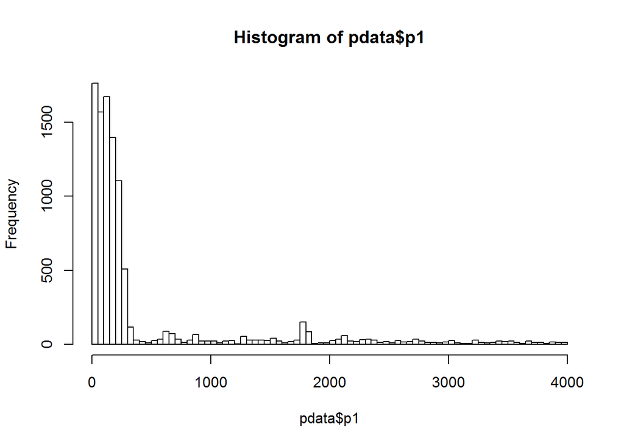

```r
hist(pdata$p1,breaks=100)
```

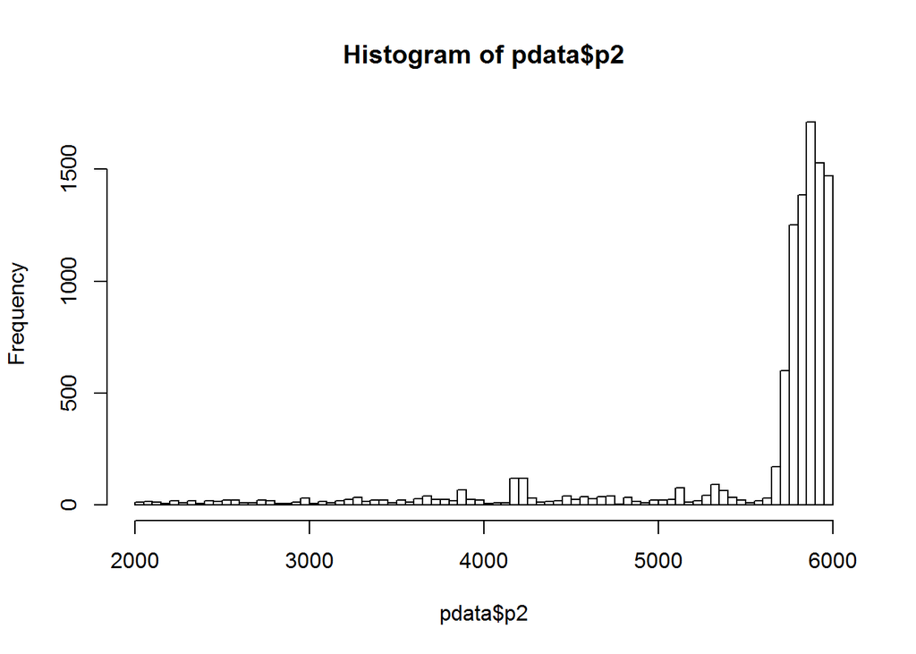

```r
hist(pdata$p2,breaks=100)

library(ggplot2)
```

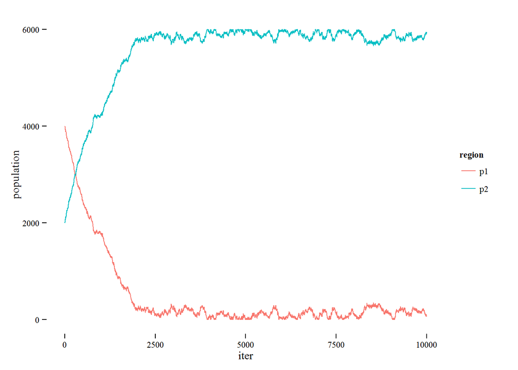

```r
library(reshape2)

library(ggthemes)

pdata$iter <- 1:length(pdata$p1)

par(mfrow=c(2,1))

pdatamelt <- melt(pdata, id.vars=c("u1","u2","iter"), measure.vars=c("p1","p2"),
                  variable.name="region", value.name="population")

ggplot(pdatamelt, aes(x=iter, y=population,color=region)) + geom_line() +
  theme_tufte()
```

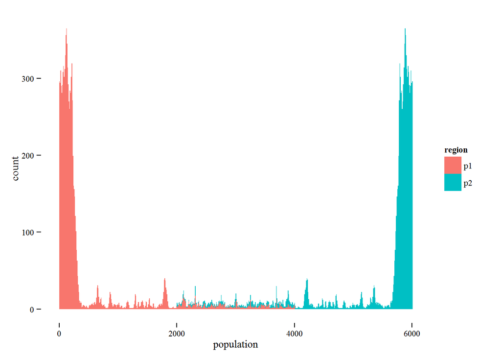

```r
ggplot(pdatamelt, aes(x=population, fill=region)) +
  geom_histogram(binwidth = 10) + theme_tufte()
```